# R notebook

Aynaz adl zarrabi

6/23/2021

## Analyse statistique et visualisation des données warhics

### importer les differents libraries

```r
library(tidyverse)
```

```r
library(readr)
library(dplyr)
library(ggplot2)
library(devtools)
library(plyr)
library(plotly)
library(matrixStats)
library(ggpubr)
library(rstatix)
```

### trouver le working directory

```python
import os
path = os.getcwd()
print(path)
```

```
## /Users/Aynaz/Documents/aynaz/libio/stat_result
```

### identifier le working directory

```r
library(reticulate)
#use_python("/Users/Aynaz/Library/r-miniconda/envs/r-reticulate/bin/python")
py_install("pandas")
py_install("numpy")
py_install("matplotlib")
py_install("seaborn")
```

### importation des donneés pour tracer les audiogrammes

```python
import pandas as pd
import numpy as np
import matplotlib.pyplot as plt
import matplotlib.ticker as ticker
import seaborn as sns
df_fin = pd.read_csv('df_fin.csv' , sep=',' , header=None)
df_fin.columns = df_fin.iloc[0]
df_fin=pd.DataFrame(df_fin)
df_fin=df_fin.drop(df_fin.index[0])
df_fin=df_fin.iloc[:, 1:]
# check records
df_fin
```

```
## 0   Warhics Level         Origin Frequency Audiometric Threshold
## 1         Level 4  Participant 1     0.125                    22
## 2         Level 5  Participant 2     0.125                    26
## 3         Level 6  Participant 3     0.125                    18
## 4         Level 7  Participant 4     0.125                    16
## 5         Level 4  Participant 5     0.125                    10
## ..            ...            ...       ...                   ...
## 128       Level 7  Participant 8         8                    68
## 129       Level 4     Humes 2021         8                    56
## 130       Level 5     Humes 2021         8                    58
## 131       Level 6     Humes 2021         8                    72
## 132       Level 7     Humes 2021         8                    77
##
## [132 rows x 4 columns]
```

```python
df_fin[["Audiometric Threshold","Frequency"]] = df_fin[["Audiometric Threshold","Frequency"]].apply(pd.to_numeric)
df_fin.dtypes
```

```
## 0
## Warhics Level             object
## Origin                    object
## Frequency                float64
## Audiometric Threshold      int64
## dtype: object
```

### Plot générale des 12 audiogrammes par origine et level

```python
ticks=[.125,.25,.5,.75,1,1.5,2,3,4,6,8]
labels = [i for i in ticks]
#sns.set_style("whitegrid")
#fig, ax = plt.subplots(figsize=(15, 10))
#sns.set_context("notebook", font_scale=2, rc={"lines.linew3idth": 4})
#sns.lineplot(
#    data=df_fin,
#    x="Frequency", y="Audiometric Threshold", hue="Warhics Level", style="Origin",markers=True, dashes=False,markersize=14)
#ax.set_xlabel('Frequency (kHz)')
#ax.set_ylabel('Audiometric threshold (dB HL)')
#ax.legend(bbox_to_anchor=(1.01, 1),borderaxespad=0)
#g.set_axis_labels("Frequence (kHz)", "Seuil Audiométrique (dBHL)")
#g.set(ylim=(90,0),xscale="log",xticks = ticks,xticklabels = labels)
#plt.savefig('plot4.png', dpi=300, bbox_inches='tight')
#plt.show()
```

[figure not shown]

Audiogram

## comparer differents approches de random search par nombre d’iteration

### importation des données

```r
df_iter<-read.csv("df_iter.csv",check.names = FALSE)
df_iter
```

```
##    id_audiogram Gen nb_iter
## 1             1   1      24
## 2             2   1      66
## 3             3   1     502
## 4             4   1      58
## 5             5   1      51
## 6             6   1      32
## 7             7   1      26
## 8             8   1      30
## 9             9   1      93
## 10           10   1       9
## 11           11   1     143
## 12           12   1      38
## 13            1   2     165
## 14            2   2     629
```

[output cut: 22 more lines]

### statistique descriptive par nombre d’iteration

```r
sum_stat_iter<-df_iter %>%
  group_by(Gen) %>%
  get_summary_stats(nb_iter, type = "mean_sd")
sum_stat_iter
```

```
## # A tibble: 3 x 5
##     Gen variable     n  mean    sd
##   <int> <chr>    <dbl> <dbl> <dbl>
## 1     1 nb_iter     12  89.3  135.
## 2     2 nb_iter     12 270.   247.
## 3     3 nb_iter     12 239.   179.
```

### boxplot des differents Gen par nombre d’iteration

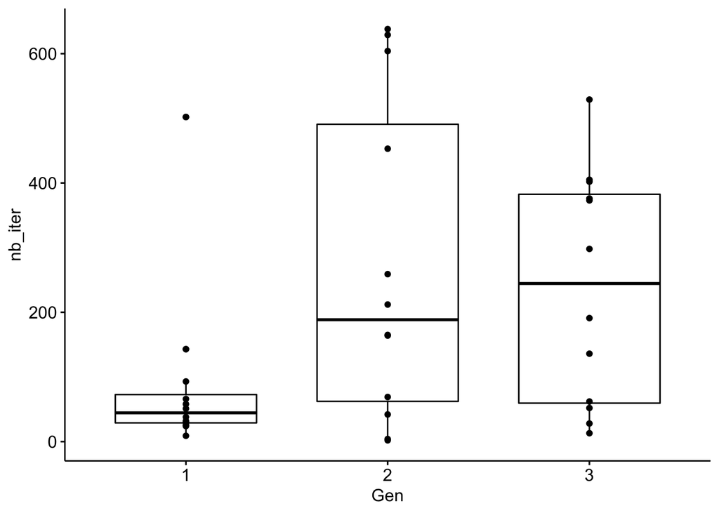

```r
bxp1 <- ggboxplot(df_iter, x = "Gen", y = "nb_iter", add = "point")
bxp1
```

### test de normalité

```r
norm_iter<-df_iter %>%
  group_by(Gen) %>%
  shapiro_test(nb_iter)
norm_iter
```

```
## # A tibble: 3 x 4
##     Gen variable statistic         p
##   <int> <chr>        <dbl>     <dbl>
## 1     1 nb_iter      0.556 0.0000470
## 2     2 nb_iter      0.860 0.0487
## 3     3 nb_iter      0.904 0.177
```

#### avec les p-values on voit que nos données ne sont pas distribués normale, et on va choisir un test non-parametrique pour comparer different approchase de random search par nombre d’iteration

### Détection des audiogrammes aberrants

```r
outliers_iter<-df_iter %>%
  group_by(Gen) %>%
  identify_outliers(nb_iter)
outliers_iter
```

```
## # A tibble: 2 x 5
##     Gen id_audiogram nb_iter is.outlier is.extreme
##   <int>        <int>   <int> <lgl>      <lgl>
## 1     1            3     502 TRUE       TRUE
## 2     1           11     143 TRUE       FALSE
```

#### parce qu’on a choisi de faire un test non-parametrique , on n’a pas besoin d’enlever les audiogrammes aberrants

### Test statistique pour les mesures répétés (friedman) non-paramétrique

```r
res.fried1 <- df_iter %>% friedman_test(nb_iter ~ Gen |id_audiogram)
res.fried1
```

```
## # A tibble: 1 x 6
##   .y.         n statistic    df     p method
## * <chr>   <int>     <dbl> <dbl> <dbl> <chr>
## 1 nb_iter    12      3.17     2 0.205 Friedman test
```

#### Le nombre d’iteration n’est pas significativement différent entre différents Gen durant les itérations, X2(2) = 3.17, p = 0,205.

## comparer differents approches de random search par score de reconnissance automatique de la parole

### importation des données

```r
df_score<-read.csv("df_score.csv",check.names = FALSE)
df_score=df_score[,-1]
df_score
```

```
##    id_audiogram Gen score
## 1             1   1  0.96
## 2             2   1  0.98
## 3             3   1  0.96
## 4             4   1  0.98
## 5             5   1  0.98
## 6             6   1  0.98
## 7             7   1  0.96
## 8             8   1  1.00
## 9             9   1  0.96
## 10           10   1  1.00
## 11           11   1  0.98
## 12           12   1  0.96
## 13            1   2  0.96
## 14            2   2  0.96
```

[output cut: 22 more lines]

### statistique descriptive par score de RAP

```r
sum_stat_score<-df_score %>%
  group_by(Gen) %>%
  get_summary_stats(score, type = "mean_sd")
sum_stat_score
```

```
## # A tibble: 3 x 5
##     Gen variable     n  mean    sd
##   <int> <chr>    <dbl> <dbl> <dbl>
## 1     1 score       12 0.975 0.015
## 2     2 score       12 0.957 0.017
## 3     3 score       12 0.955 0.017
```

### boxplot des differents Gen par score de RAP

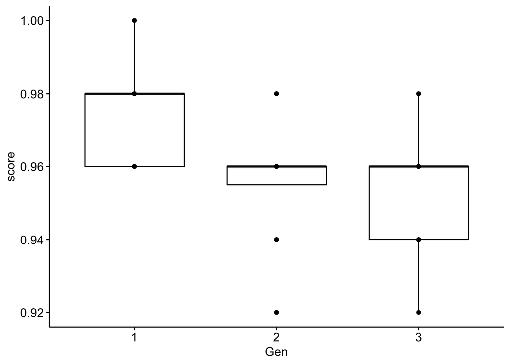

```r
bxp2 <- ggboxplot(df_score, x = "Gen", y = "score", add = "point")
bxp2
```

### test de normalité

```r
norm_score<-df_score %>%
  group_by(Gen) %>%
  shapiro_test(score)
norm_score
```

```
## # A tibble: 3 x 4
##     Gen variable statistic      p
##   <int> <chr>        <dbl>  <dbl>
## 1     1 score        0.807 0.0113
## 2     2 score        0.843 0.0300
## 3     3 score        0.884 0.0992
```

#### avec les p-values on voit que nos données ne sont pas distribués normale, et on va choisir un test non-parametrique pour comparer different approchase de random search par score de RAP

### Détection des audiogrammes aberrants

```r
outliers_score<-df_score %>%
  group_by(Gen) %>%
  identify_outliers(score)
outliers_score
```

```
## # A tibble: 5 x 5
##     Gen id_audiogram score is.outlier is.extreme
##   <int>        <int> <dbl> <lgl>      <lgl>
## 1     2            7  0.94 TRUE       FALSE
## 2     2            8  0.92 TRUE       TRUE
## 3     2            9  0.94 TRUE       FALSE
## 4     2           10  0.98 TRUE       TRUE
## 5     2           12  0.98 TRUE       TRUE
```

#### parce qu’on a choisi de faire un test non-parametrique , on n’a pas besoin d’enlever les audiogrammes aberrants

### Test statistique pour les mesures répétés (friedman) non-paramétrique

```r
res.fried2 <- df_score %>% friedman_test(score ~ Gen |id_audiogram)
res.fried2
```

```
## # A tibble: 1 x 6
##   .y.       n statistic    df       p method
## * <chr> <int>     <dbl> <dbl>   <dbl> <chr>
## 1 score    12      11.8     2 0.00269 Friedman test
```

### Test post hoc de mesure repetes non parametrique (wilcoxon)

```r
pwc_fried_score <- df_score %>%
  wilcox_test(score ~ Gen, paired = TRUE, p.adjust.method = "bonferroni")
pwc_fried_score
```

```
## # A tibble: 3 x 9
##   .y.   group1 group2    n1    n2 statistic     p p.adj p.adj.signif
## * <chr> <chr>  <chr>  <int> <int>     <dbl> <dbl> <dbl> <chr>
## 1 score 1      2         12    12        50 0.015 0.044 *
## 2 score 1      3         12    12        61 0.009 0.028 *
## 3 score 2      3         12    12         8 1     1     ns
```

### boxplot avec les test de posthocs

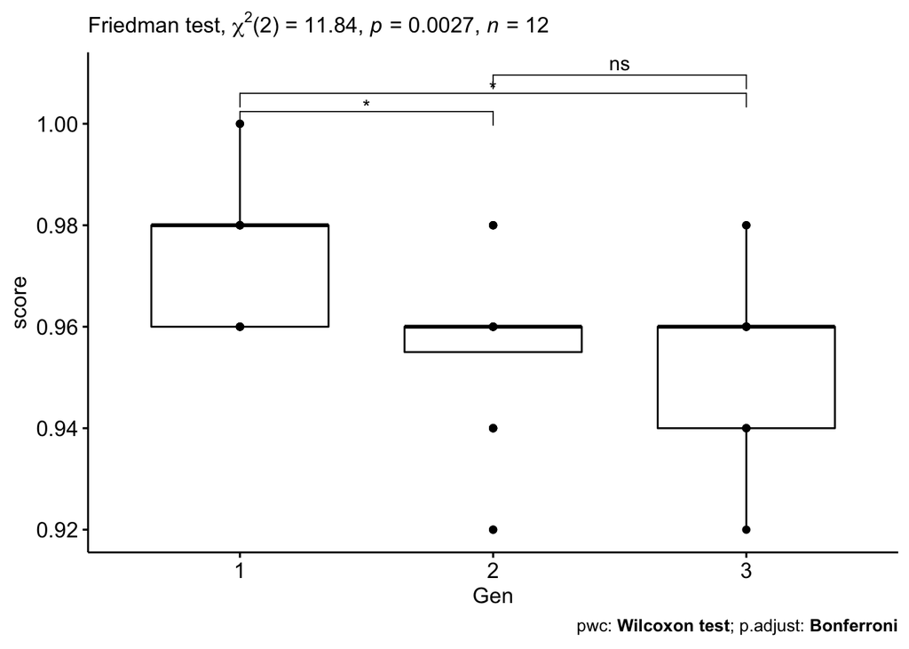

```r
pwc_fried_score <- pwc_fried_score %>% add_xy_position(x = "Gen")
ggboxplot(df_score, x = "Gen", y = "score", add = "point") +
  stat_pvalue_manual(pwc_fried_score, hide.ns = FALSE) +
  labs(
    subtitle = get_test_label(res.fried2,  detailed = TRUE),
    caption = get_pwc_label(pwc_fried_score)
  )
```

## comparer differents approches de random search par score de reconnissance automatique de la parole et par 2 methodes de (OPRA2 et CAM2)

### importation des données

```r
df_method<-read.csv("df_method.csv",check.names = FALSE)
df_method=df_method[,-1]
str(df_method)
```

```
## 'data.frame':    72 obs. of  4 variables:
##  $ id_audiogram: int  1 1 2 2 3 3 4 4 5 5 ...
##  $ method      : chr  "CAM2" "OPRA" "CAM2" "OPRA" ...
##  $ Gen         : chr  "GEN1" "GEN1" "GEN1" "GEN1" ...
##  $ score       : num  0.9 0.96 0.9 0.98 0.92 0.96 0.9 0.98 0.78 0.98 ...
```

```r
df_method <- df_method %>%
  convert_as_factor(id_audiogram, method,Gen)
```

### statistique descriptive par score de RAP

```r
sum_stat_method<-df_method %>%
  group_by(method, Gen) %>%
  get_summary_stats(score, type = "mean_sd")
sum_stat_method
```

```
## # A tibble: 6 x 6
##   method Gen   variable     n  mean    sd
##   <fct>  <fct> <chr>    <dbl> <dbl> <dbl>
## 1 CAM2   GEN1  score       12 0.845 0.083
## 2 CAM2   GEN2  score       12 0.843 0.078
## 3 CAM2   GEN3  score       12 0.922 0.042
## 4 OPRA   GEN1  score       12 0.975 0.015
## 5 OPRA   GEN2  score       12 0.957 0.017
## 6 OPRA   GEN3  score       12 0.955 0.017
```

### boxplot des differents Gen par score de RAP

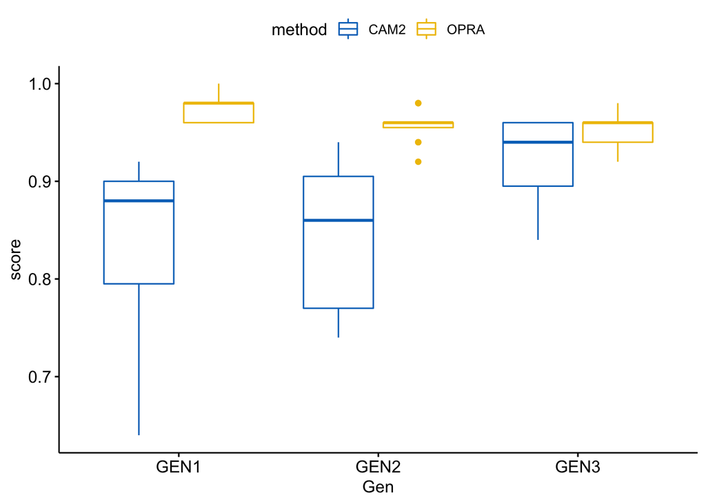

```r
bxp3 <- ggboxplot(
  df_method, x = "Gen", y = "score",
  color = "method", palette = "jco"
)
bxp3
```

## test de normalité

```r
norm_method<-df_method %>%
  group_by(method, Gen) %>%
  shapiro_test(score)
norm_method
```

```
## # A tibble: 6 x 5
##   method Gen   variable statistic      p
##   <fct>  <fct> <chr>        <dbl>  <dbl>
## 1 CAM2   GEN1  score        0.825 0.0185
## 2 CAM2   GEN2  score        0.888 0.111
## 3 CAM2   GEN3  score        0.852 0.0385
## 4 OPRA   GEN1  score        0.807 0.0113
## 5 OPRA   GEN2  score        0.843 0.0300
## 6 OPRA   GEN3  score        0.884 0.0992
```

#### avec les p-values on voit que nos données ne sont pas distribués normale, et on va choisir un test non-parametrique pour comparer different approchase de random search par score de RAP et par les deux differents methodes

### Détection des audiogrammes aberrants : parce qu’on a choisi de faire un test non-parametrique , on n’a pas besoin d’enlever les audiogrammes aberrants

```r
outliers_method<-df_method %>%
  group_by(method, Gen) %>%
  identify_outliers(score)
outliers_method
```

```
## # A tibble: 5 x 6
##   method Gen   id_audiogram score is.outlier is.extreme
##   <fct>  <fct> <fct>        <dbl> <lgl>      <lgl>
## 1 OPRA   GEN2  7             0.94 TRUE       FALSE
## 2 OPRA   GEN2  8             0.92 TRUE       TRUE
## 3 OPRA   GEN2  9             0.94 TRUE       FALSE
## 4 OPRA   GEN2  10            0.98 TRUE       TRUE
## 5 OPRA   GEN2  12            0.98 TRUE       TRUE
```

### Test statistique pour les mesures répétés à 2 facteurs non-paramétrique #Aligned Rank Transform for Nonparametric Factorial ANOVAs

```r
library(ARTool)
m <- art(score ~ method*Gen + Error(id_audiogram), data=df_method)
anova(m)
```

```
## Analysis of Variance of Aligned Rank Transformed Data
##
## Table Type: Repeated Measures Analysis of Variance Table (Type I)
## Model: Repeated Measures (aov)
## Response: art(score)
##
##              Error Df Df.res  F value     Pr(>F)
## 1 method     Withn  1     55 158.0915 < 2.22e-16 ***
## 2 Gen        Withn  2     55   7.0692 0.00185229  **
## 3 method:Gen Withn  2     55  10.1475 0.00017738 ***
## ---
## Signif. codes:   0 '***' 0.001 '**' 0.01 '*' 0.05 '.' 0.1 ' ' 1
```

#### Il existe une interaction significative entre la variable methode et la variable Gen et on va regarder precisement entre chaque groupe et chaque methode la difference siginificaive et on va les tracer sur le ggplot.

```r
library(dplyr)
pwc_method<-art.con(m, "method:Gen", adjust="holm") %>%
          summary() %>%
          mutate(sig. = symnum(p.value, corr=FALSE, na=FALSE,
                               cutpoints = c(0, 0.001, 0.01, 0.05, 0.1, 1),
                               symbols = c("***", "**", "*", ".", " ")))
pwc_method
```

```
##  contrast              estimate   SE df t.ratio p.value sig.
##  CAM2,GEN1 - CAM2,GEN2   -0.208 4.17 55  -0.050 1.0000
##  CAM2,GEN1 - CAM2,GEN3  -17.708 4.17 55  -4.243 0.0007  ***
##  CAM2,GEN1 - OPRA,GEN1  -45.417 4.17 55 -10.882 <.0001  ***
##  CAM2,GEN1 - OPRA,GEN2  -33.375 4.17 55  -7.997 <.0001  ***
##  CAM2,GEN1 - OPRA,GEN3  -32.042 4.17 55  -7.677 <.0001  ***
##  CAM2,GEN2 - CAM2,GEN3  -17.500 4.17 55  -4.193 0.0007  ***
##  CAM2,GEN2 - OPRA,GEN1  -45.208 4.17 55 -10.832 <.0001  ***
##  CAM2,GEN2 - OPRA,GEN2  -33.167 4.17 55  -7.947 <.0001  ***
##  CAM2,GEN2 - OPRA,GEN3  -31.833 4.17 55  -7.628 <.0001  ***
##  CAM2,GEN3 - OPRA,GEN1  -27.708 4.17 55  -6.639 <.0001  ***
##  CAM2,GEN3 - OPRA,GEN2  -15.667 4.17 55  -3.754 0.0025  **
##  CAM2,GEN3 - OPRA,GEN3  -14.333 4.17 55  -3.434 0.0057  **
##  OPRA,GEN1 - OPRA,GEN2   12.042 4.17 55   2.885 0.0167  *
##  OPRA,GEN1 - OPRA,GEN3   13.375 4.17 55   3.205 0.0090  **
##  OPRA,GEN2 - OPRA,GEN3    1.333 4.17 55   0.319 1.0000
##
## P value adjustment: holm method for 15 tests
```

#### entre CAM2 et OPRA2 il y a une difference significative dans tous les different groupe de GEN

### boxplot avec les test de posthocs

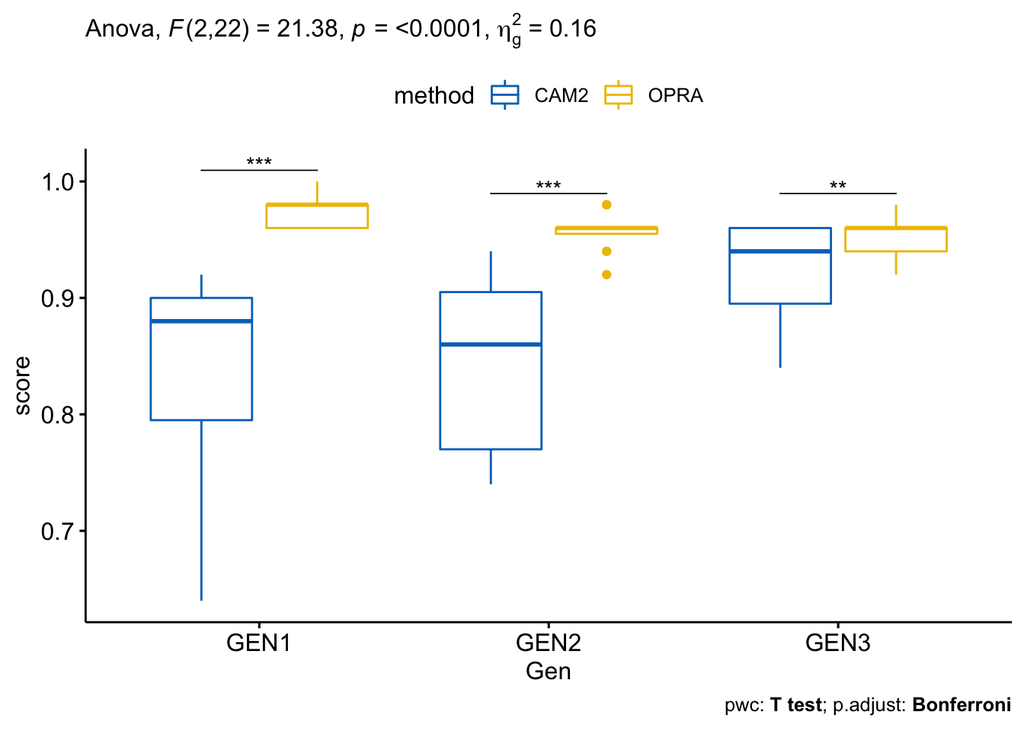

```r
res.aov3 <- anova_test(
  data = df_method, dv = score, wid = id_audiogram,
  within = c(method, Gen)
)
pwc_method<-df_method %>%
  group_by(Gen) %>%
  pairwise_t_test(
    score ~ method, paired = TRUE,
    p.adjust.method = "bonferroni"
  )
pwc_method <- pwc_method %>% add_xy_position(x = "Gen")
bxp3 +
  stat_pvalue_manual(pwc_method, tip.length = 0, hide.ns = TRUE) +
  labs(
    subtitle = get_test_label(res.aov3, detailed = TRUE),
    caption = get_pwc_label(pwc_method)
  )
```